# Risk Factor Analysis

## Outcome Variable

**Outcome Variable:** pers_wast

## Predictor Variables

**Intervention Variable:** predfeed36

**Adjustment Set:**

unadjusted

## Stratifying Variables

The analysis was stratified on these variable(s):

- agecat
- studyid
- country

## Data Summary

| agecat | studyid | country | predfeed36 | pers_wast | n_cell | n |
| --- | --- | --- | --- | --- | --- | --- |
| 0-24 months | ki0047075b-MAL-ED | BANGLADESH | 0 | 0 | 110 | 247 |
| 0-24 months | ki0047075b-MAL-ED | BANGLADESH | 0 | 1 | 6 | 247 |
| 0-24 months | ki0047075b-MAL-ED | BANGLADESH | 1 | 0 | 124 | 247 |
| 0-24 months | ki0047075b-MAL-ED | BANGLADESH | 1 | 1 | 7 | 247 |
| 0-24 months | ki0047075b-MAL-ED | BRAZIL | 0 | 0 | 178 | 217 |
| 0-24 months | ki0047075b-MAL-ED | BRAZIL | 0 | 1 | 1 | 217 |
| 0-24 months | ki0047075b-MAL-ED | BRAZIL | 1 | 0 | 37 | 217 |
| 0-24 months | ki0047075b-MAL-ED | BRAZIL | 1 | 1 | 1 | 217 |
| 0-24 months | ki0047075b-MAL-ED | INDIA | 0 | 0 | 200 | 241 |
| 0-24 months | ki0047075b-MAL-ED | INDIA | 0 | 1 | 21 | 241 |
| 0-24 months | ki0047075b-MAL-ED | INDIA | 1 | 0 | 20 | 241 |
| 0-24 months | ki0047075b-MAL-ED | INDIA | 1 | 1 | 0 | 241 |
| 0-24 months | ki0047075b-MAL-ED | NEPAL | 0 | 0 | 202 | 238 |
| 0-24 months | ki0047075b-MAL-ED | NEPAL | 0 | 1 | 4 | 238 |
| 0-24 months | ki0047075b-MAL-ED | NEPAL | 1 | 0 | 32 | 238 |
| 0-24 months | ki0047075b-MAL-ED | NEPAL | 1 | 1 | 0 | 238 |
| 0-24 months | ki0047075b-MAL-ED | PERU | 0 | 0 | 155 | 282 |
| 0-24 months | ki0047075b-MAL-ED | PERU | 0 | 1 | 0 | 282 |
| 0-24 months | ki0047075b-MAL-ED | PERU | 1 | 0 | 126 | 282 |
| 0-24 months | ki0047075b-MAL-ED | PERU | 1 | 1 | 1 | 282 |
| 0-24 months | ki0047075b-MAL-ED | SOUTH AFRICA | 0 | 0 | 268 | 273 |
| 0-24 months | ki0047075b-MAL-ED | SOUTH AFRICA | 0 | 1 | 2 | 273 |
| 0-24 months | ki0047075b-MAL-ED | SOUTH AFRICA | 1 | 0 | 3 | 273 |
| 0-24 months | ki0047075b-MAL-ED | SOUTH AFRICA | 1 | 1 | 0 | 273 |
| 0-24 months | ki0047075b-MAL-ED | TANZANIA, UNITED REPUBLIC OF | 0 | 0 | 251 | 253 |
| 0-24 months | ki0047075b-MAL-ED | TANZANIA, UNITED REPUBLIC OF | 0 | 1 | 0 | 253 |
| 0-24 months | ki0047075b-MAL-ED | TANZANIA, UNITED REPUBLIC OF | 1 | 0 | 2 | 253 |
| 0-24 months | ki0047075b-MAL-ED | TANZANIA, UNITED REPUBLIC OF | 1 | 1 | 0 | 253 |
| 0-24 months | ki1000109-EE | PAKISTAN | 0 | 0 | 134 | 372 |
| 0-24 months | ki1000109-EE | PAKISTAN | 0 | 1 | 13 | 372 |

[output cut: 106 more lines]

The following strata were considered:

- agecat: 0-24 months, studyid: ki0047075b-MAL-ED, country: BANGLADESH
- agecat: 0-24 months, studyid: ki0047075b-MAL-ED, country: BRAZIL
- agecat: 0-24 months, studyid: ki0047075b-MAL-ED, country: INDIA
- agecat: 0-24 months, studyid: ki0047075b-MAL-ED, country: NEPAL
- agecat: 0-24 months, studyid: ki0047075b-MAL-ED, country: PERU
- agecat: 0-24 months, studyid: ki0047075b-MAL-ED, country: SOUTH AFRICA
- agecat: 0-24 months, studyid: ki0047075b-MAL-ED, country: TANZANIA, UNITED REPUBLIC OF
- agecat: 0-24 months, studyid: ki1000109-EE, country: PAKISTAN
- agecat: 0-24 months, studyid: ki1000304b-SAS-FoodSuppl, country: INDIA
- agecat: 0-24 months, studyid: ki1113344-GMS-Nepal, country: NEPAL
- agecat: 0-24 months, studyid: ki1148112-LCNI-5, country: MALAWI
- agecat: 0-24 months, studyid: kiGH5241-JiVitA-3, country: BANGLADESH
- agecat: 0-24 months, studyid: kiGH5241-JiVitA-4, country: BANGLADESH
- agecat: 0-6 months, studyid: ki0047075b-MAL-ED, country: BANGLADESH
- agecat: 0-6 months, studyid: ki0047075b-MAL-ED, country: BRAZIL
- agecat: 0-6 months, studyid: ki0047075b-MAL-ED, country: INDIA
- agecat: 0-6 months, studyid: ki0047075b-MAL-ED, country: NEPAL
- agecat: 0-6 months, studyid: ki0047075b-MAL-ED, country: PERU
- agecat: 0-6 months, studyid: ki0047075b-MAL-ED, country: SOUTH AFRICA
- agecat: 0-6 months, studyid: ki0047075b-MAL-ED, country: TANZANIA, UNITED REPUBLIC OF
- agecat: 0-6 months, studyid: ki1000109-EE, country: PAKISTAN
- agecat: 0-6 months, studyid: ki1113344-GMS-Nepal, country: NEPAL
- agecat: 6-24 months, studyid: ki0047075b-MAL-ED, country: BANGLADESH
- agecat: 6-24 months, studyid: ki0047075b-MAL-ED, country: BRAZIL
- agecat: 6-24 months, studyid: ki0047075b-MAL-ED, country: INDIA
- agecat: 6-24 months, studyid: ki0047075b-MAL-ED, country: NEPAL
- agecat: 6-24 months, studyid: ki0047075b-MAL-ED, country: PERU
- agecat: 6-24 months, studyid: ki0047075b-MAL-ED, country: SOUTH AFRICA
- agecat: 6-24 months, studyid: ki0047075b-MAL-ED, country: TANZANIA, UNITED REPUBLIC OF
- agecat: 6-24 months, studyid: ki1000109-EE, country: PAKISTAN
- agecat: 6-24 months, studyid: ki1000304b-SAS-FoodSuppl, country: INDIA
- agecat: 6-24 months, studyid: ki1113344-GMS-Nepal, country: NEPAL
- agecat: 6-24 months, studyid: ki1148112-LCNI-5, country: MALAWI
- agecat: 6-24 months, studyid: kiGH5241-JiVitA-4, country: BANGLADESH

### Dropped Strata

Some strata were dropped due to rare outcomes:

- agecat: 0-24 months, studyid: ki0047075b-MAL-ED, country: BRAZIL
- agecat: 0-24 months, studyid: ki0047075b-MAL-ED, country: INDIA
- agecat: 0-24 months, studyid: ki0047075b-MAL-ED, country: NEPAL
- agecat: 0-24 months, studyid: ki0047075b-MAL-ED, country: PERU
- agecat: 0-24 months, studyid: ki0047075b-MAL-ED, country: SOUTH AFRICA
- agecat: 0-24 months, studyid: ki0047075b-MAL-ED, country: TANZANIA, UNITED REPUBLIC OF
- agecat: 0-24 months, studyid: ki1000304b-SAS-FoodSuppl, country: INDIA
- agecat: 0-24 months, studyid: ki1148112-LCNI-5, country: MALAWI
- agecat: 0-6 months, studyid: ki0047075b-MAL-ED, country: BANGLADESH
- agecat: 0-6 months, studyid: ki0047075b-MAL-ED, country: BRAZIL
- agecat: 0-6 months, studyid: ki0047075b-MAL-ED, country: INDIA
- agecat: 0-6 months, studyid: ki0047075b-MAL-ED, country: NEPAL
- agecat: 0-6 months, studyid: ki0047075b-MAL-ED, country: PERU
- agecat: 0-6 months, studyid: ki0047075b-MAL-ED, country: SOUTH AFRICA
- agecat: 0-6 months, studyid: ki0047075b-MAL-ED, country: TANZANIA, UNITED REPUBLIC OF
- agecat: 6-24 months, studyid: ki0047075b-MAL-ED, country: BRAZIL
- agecat: 6-24 months, studyid: ki0047075b-MAL-ED, country: INDIA
- agecat: 6-24 months, studyid: ki0047075b-MAL-ED, country: NEPAL
- agecat: 6-24 months, studyid: ki0047075b-MAL-ED, country: PERU
- agecat: 6-24 months, studyid: ki0047075b-MAL-ED, country: SOUTH AFRICA
- agecat: 6-24 months, studyid: ki0047075b-MAL-ED, country: TANZANIA, UNITED REPUBLIC OF
- agecat: 6-24 months, studyid: ki1000304b-SAS-FoodSuppl, country: INDIA
- agecat: 6-24 months, studyid: ki1148112-LCNI-5, country: MALAWI

## Methods Detail

We’re interested in the causal parameters $E[Y_a]$ for all values of $a \in \mathcal{A}$. These parameters represent the mean outcome if, possibly contrary to fact, we intervened to set all units to have $A=a$. Under the randomization and positivity assumptions, these are identified by the statistical parameters $\psi_a=E_W[E_{Y|A,W}(Y|A=a,W)]$. In addition, we’re interested in the mean of $Y$, $E[Y]$ under no intervention (the observed mean). We will estimate these parameters by using SuperLearner to fit the relevant likelihood factors – $E_{Y|A,W}(Y|A=a,W)$ and $p(A=a|W)$, and then updating our likelihood fit using a joint TMLE.

For unadjusted analyses ($W=\{\}$), initial likelihoods were estimated using Lrnr_glm to estimate the simple $E(Y|A)$ and Lrnr_mean to estimate $p(A)$. For adjusted analyses, a small library containing Lrnr_glmnet, Lrnr_xgboost, and Lrnr_mean was used.

Having estimated these parameters, we will then use the delta method to estimate relative risks and attributable risks relative to a prespecified baseline level of $A$.

# Results Detail

## Results Plots

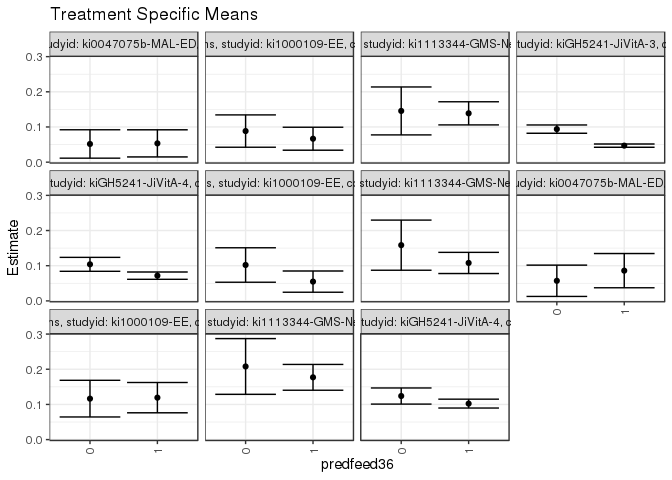

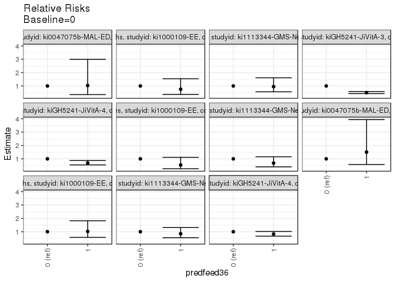

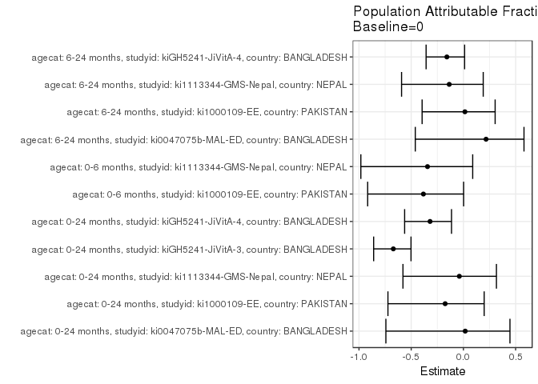

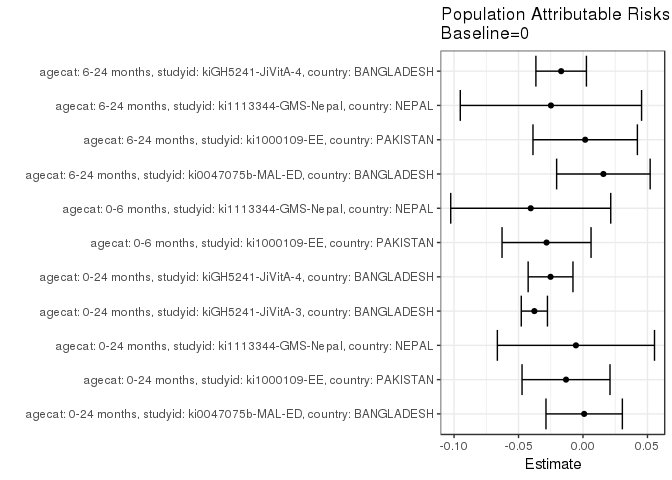

## Results Table

### Parameter: TSM

| agecat | studyid | country | intervention_level | baseline_level | estimate | ci_lower | ci_upper |
| --- | --- | --- | --- | --- | --- | --- | --- |
| 0-24 months | ki0047075b-MAL-ED | BANGLADESH | 0 | NA | 0.0517241 | 0.0113397 | 0.0921086 |
| 0-24 months | ki0047075b-MAL-ED | BANGLADESH | 1 | NA | 0.0534351 | 0.0148445 | 0.0920258 |
| 0-24 months | ki1000109-EE | PAKISTAN | 0 | NA | 0.0884354 | 0.0424753 | 0.1343954 |
| 0-24 months | ki1000109-EE | PAKISTAN | 1 | NA | 0.0666667 | 0.0340294 | 0.0993040 |
| 0-24 months | ki1113344-GMS-Nepal | NEPAL | 0 | NA | 0.1456311 | 0.0774457 | 0.2138164 |
| 0-24 months | ki1113344-GMS-Nepal | NEPAL | 1 | NA | 0.1388235 | 0.1059200 | 0.1717271 |
| 0-24 months | kiGH5241-JiVitA-3 | BANGLADESH | 0 | NA | 0.0939117 | 0.0821237 | 0.1056996 |
| 0-24 months | kiGH5241-JiVitA-3 | BANGLADESH | 1 | NA | 0.0469903 | 0.0423540 | 0.0516266 |
| 0-24 months | kiGH5241-JiVitA-4 | BANGLADESH | 0 | NA | 0.1039095 | 0.0841317 | 0.1236872 |
| 0-24 months | kiGH5241-JiVitA-4 | BANGLADESH | 1 | NA | 0.0717553 | 0.0613925 | 0.0821181 |
| 0-6 months | ki1000109-EE | PAKISTAN | 0 | NA | 0.1020408 | 0.0530405 | 0.1510411 |
| 0-6 months | ki1000109-EE | PAKISTAN | 1 | NA | 0.0547945 | 0.0246123 | 0.0849768 |
| 0-6 months | ki1113344-GMS-Nepal | NEPAL | 0 | NA | 0.1584158 | 0.0871367 | 0.2296950 |
| 0-6 months | ki1113344-GMS-Nepal | NEPAL | 1 | NA | 0.1078431 | 0.0777157 | 0.1379706 |
| 6-24 months | ki0047075b-MAL-ED | BANGLADESH | 0 | NA | 0.0571429 | 0.0126499 | 0.1016358 |
| 6-24 months | ki0047075b-MAL-ED | BANGLADESH | 1 | NA | 0.0859375 | 0.0372793 | 0.1345957 |
| 6-24 months | ki1000109-EE | PAKISTAN | 0 | NA | 0.1164384 | 0.0643386 | 0.1685381 |
| 6-24 months | ki1000109-EE | PAKISTAN | 1 | NA | 0.1192661 | 0.0761838 | 0.1623483 |
| 6-24 months | ki1113344-GMS-Nepal | NEPAL | 0 | NA | 0.2079208 | 0.1286999 | 0.2871416 |
| 6-24 months | ki1113344-GMS-Nepal | NEPAL | 1 | NA | 0.1770335 | 0.1404068 | 0.2136602 |
| 6-24 months | kiGH5241-JiVitA-4 | BANGLADESH | 0 | NA | 0.1239130 | 0.1009902 | 0.1468359 |
| 6-24 months | kiGH5241-JiVitA-4 | BANGLADESH | 1 | NA | 0.1023270 | 0.0896849 | 0.1149690 |

### Parameter: E(Y)

| agecat | studyid | country | intervention_level | baseline_level | estimate | ci_lower | ci_upper |
| --- | --- | --- | --- | --- | --- | --- | --- |
| 0-24 months | ki0047075b-MAL-ED | BANGLADESH | NA | NA | 0.0526316 | 0.0247278 | 0.0805354 |
| 0-24 months | ki1000109-EE | PAKISTAN | NA | NA | 0.0752688 | 0.0484230 | 0.1021146 |
| 0-24 months | ki1113344-GMS-Nepal | NEPAL | NA | NA | 0.1401515 | 0.1105133 | 0.1697898 |
| 0-24 months | kiGH5241-JiVitA-3 | BANGLADESH | NA | NA | 0.0561929 | 0.0517926 | 0.0605933 |
| 0-24 months | kiGH5241-JiVitA-4 | BANGLADESH | NA | NA | 0.0787472 | 0.0695071 | 0.0879873 |
| 0-6 months | ki1000109-EE | PAKISTAN | NA | NA | 0.0737705 | 0.0469540 | 0.1005870 |
| 0-6 months | ki1113344-GMS-Nepal | NEPAL | NA | NA | 0.1178782 | 0.0898370 | 0.1459194 |
| 6-24 months | ki0047075b-MAL-ED | BANGLADESH | NA | NA | 0.0729614 | 0.0394957 | 0.1064270 |
| 6-24 months | ki1000109-EE | PAKISTAN | NA | NA | 0.1181319 | 0.0849287 | 0.1513351 |
| 6-24 months | ki1113344-GMS-Nepal | NEPAL | NA | NA | 0.1830443 | 0.1497431 | 0.2163456 |
| 6-24 months | kiGH5241-JiVitA-4 | BANGLADESH | NA | NA | 0.1069757 | 0.0954392 | 0.1185121 |

### Parameter: RR

| agecat | studyid | country | intervention_level | baseline_level | estimate | ci_lower | ci_upper |
| --- | --- | --- | --- | --- | --- | --- | --- |
| 0-24 months | ki0047075b-MAL-ED | BANGLADESH | 0 | 0 | 1.0000000 | 1.0000000 | 1.0000000 |
| 0-24 months | ki0047075b-MAL-ED | BANGLADESH | 1 | 0 | 1.0330789 | 0.3566438 | 2.9924868 |
| 0-24 months | ki1000109-EE | PAKISTAN | 0 | 0 | 1.0000000 | 1.0000000 | 1.0000000 |
| 0-24 months | ki1000109-EE | PAKISTAN | 1 | 0 | 0.7538462 | 0.3691541 | 1.5394220 |
| 0-24 months | ki1113344-GMS-Nepal | NEPAL | 0 | 0 | 1.0000000 | 1.0000000 | 1.0000000 |
| 0-24 months | ki1113344-GMS-Nepal | NEPAL | 1 | 0 | 0.9532549 | 0.5640272 | 1.6110834 |
| 0-24 months | kiGH5241-JiVitA-3 | BANGLADESH | 0 | 0 | 1.0000000 | 1.0000000 | 1.0000000 |
| 0-24 months | kiGH5241-JiVitA-3 | BANGLADESH | 1 | 0 | 0.5003670 | 0.4267432 | 0.5866927 |
| 0-24 months | kiGH5241-JiVitA-4 | BANGLADESH | 0 | 0 | 1.0000000 | 1.0000000 | 1.0000000 |
| 0-24 months | kiGH5241-JiVitA-4 | BANGLADESH | 1 | 0 | 0.6905558 | 0.5449174 | 0.8751187 |
| 0-6 months | ki1000109-EE | PAKISTAN | 0 | 0 | 1.0000000 | 1.0000000 | 1.0000000 |
| 0-6 months | ki1000109-EE | PAKISTAN | 1 | 0 | 0.5369863 | 0.2585829 | 1.1151328 |
| 0-6 months | ki1113344-GMS-Nepal | NEPAL | 0 | 0 | 1.0000000 | 1.0000000 | 1.0000000 |
| 0-6 months | ki1113344-GMS-Nepal | NEPAL | 1 | 0 | 0.6807598 | 0.4008504 | 1.1561267 |
| 6-24 months | ki0047075b-MAL-ED | BANGLADESH | 0 | 0 | 1.0000000 | 1.0000000 | 1.0000000 |
| 6-24 months | ki0047075b-MAL-ED | BANGLADESH | 1 | 0 | 1.5039062 | 0.5742655 | 3.9384816 |
| 6-24 months | ki1000109-EE | PAKISTAN | 0 | 0 | 1.0000000 | 1.0000000 | 1.0000000 |
| 6-24 months | ki1000109-EE | PAKISTAN | 1 | 0 | 1.0242849 | 0.5763364 | 1.8203946 |
| 6-24 months | ki1113344-GMS-Nepal | NEPAL | 0 | 0 | 1.0000000 | 1.0000000 | 1.0000000 |
| 6-24 months | ki1113344-GMS-Nepal | NEPAL | 1 | 0 | 0.8514468 | 0.5519045 | 1.3135637 |
| 6-24 months | kiGH5241-JiVitA-4 | BANGLADESH | 0 | 0 | 1.0000000 | 1.0000000 | 1.0000000 |
| 6-24 months | kiGH5241-JiVitA-4 | BANGLADESH | 1 | 0 | 0.8257966 | 0.6686447 | 1.0198840 |

### Parameter: PAR

| agecat | studyid | country | intervention_level | baseline_level | estimate | ci_lower | ci_upper |
| --- | --- | --- | --- | --- | --- | --- | --- |
| 0-24 months | ki0047075b-MAL-ED | BANGLADESH | 0 | NA | 0.0009074 | -0.0287180 | 0.0305328 |
| 0-24 months | ki1000109-EE | PAKISTAN | 0 | NA | -0.0131666 | -0.0472782 | 0.0209451 |
| 0-24 months | ki1113344-GMS-Nepal | NEPAL | 0 | NA | -0.0054796 | -0.0664202 | 0.0554610 |
| 0-24 months | kiGH5241-JiVitA-3 | BANGLADESH | 0 | NA | -0.0377187 | -0.0478706 | -0.0275668 |
| 0-24 months | kiGH5241-JiVitA-4 | BANGLADESH | 0 | NA | -0.0251623 | -0.0425419 | -0.0077826 |
| 0-6 months | ki1000109-EE | PAKISTAN | 0 | NA | -0.0282703 | -0.0627878 | 0.0062472 |
| 0-6 months | ki1113344-GMS-Nepal | NEPAL | 0 | NA | -0.0405376 | -0.1025918 | 0.0215165 |
| 6-24 months | ki0047075b-MAL-ED | BANGLADESH | 0 | NA | 0.0158185 | -0.0204494 | 0.0520865 |
| 6-24 months | ki1000109-EE | PAKISTAN | 0 | NA | 0.0016935 | -0.0387956 | 0.0421826 |
| 6-24 months | ki1113344-GMS-Nepal | NEPAL | 0 | NA | -0.0248765 | -0.0951777 | 0.0454247 |
| 6-24 months | kiGH5241-JiVitA-4 | BANGLADESH | 0 | NA | -0.0169374 | -0.0365312 | 0.0026565 |

### Parameter: PAF

| agecat | studyid | country | intervention_level | baseline_level | estimate | ci_lower | ci_upper |
| --- | --- | --- | --- | --- | --- | --- | --- |
| 0-24 months | ki0047075b-MAL-ED | BANGLADESH | 0 | NA | 0.0172414 | -0.7424613 | 0.4457182 |
| 0-24 months | ki1000109-EE | PAKISTAN | 0 | NA | -0.1749271 | -0.7228204 | 0.1987245 |
| 0-24 months | ki1113344-GMS-Nepal | NEPAL | 0 | NA | -0.0390973 | -0.5789517 | 0.3161771 |
| 0-24 months | kiGH5241-JiVitA-3 | BANGLADESH | 0 | NA | -0.6712362 | -0.8596950 | -0.5018755 |
| 0-24 months | kiGH5241-JiVitA-4 | BANGLADESH | 0 | NA | -0.3195321 | -0.5629985 | -0.1139902 |
| 0-6 months | ki1000109-EE | PAKISTAN | 0 | NA | -0.3832200 | -0.9170506 | 0.0019578 |
| 0-6 months | ki1113344-GMS-Nepal | NEPAL | 0 | NA | -0.3438944 | -0.9822754 | 0.0888995 |
| 6-24 months | ki0047075b-MAL-ED | BANGLADESH | 0 | NA | 0.2168067 | -0.4609385 | 0.5801386 |
| 6-24 months | ki1000109-EE | PAKISTAN | 0 | NA | 0.0143358 | -0.3955274 | 0.3038231 |
| 6-24 months | ki1113344-GMS-Nepal | NEPAL | 0 | NA | -0.1359041 | -0.5923325 | 0.1896930 |
| 6-24 months | kiGH5241-JiVitA-4 | BANGLADESH | 0 | NA | -0.1583294 | -0.3573247 | 0.0114916 |